# Lecture 09 - PCA and Hierarchical Clustering

Matt Demelo

4/30/2019

## Part 1: Preparing Wisconsin cancer data for PCA

```r
wisc.df <- read.csv("WisconsinCancer.csv")

head(wisc.df)
```

```
##         id diagnosis radius_mean texture_mean perimeter_mean area_mean
## 1   842302         M       17.99        10.38         122.80    1001.0
## 2   842517         M       20.57        17.77         132.90    1326.0
## 3 84300903         M       19.69        21.25         130.00    1203.0
## 4 84348301         M       11.42        20.38          77.58     386.1
## 5 84358402         M       20.29        14.34         135.10    1297.0
## 6   843786         M       12.45        15.70          82.57     477.1
##   smoothness_mean compactness_mean concavity_mean concave.points_mean
## 1         0.11840          0.27760         0.3001             0.14710
## 2         0.08474          0.07864         0.0869             0.07017
## 3         0.10960          0.15990         0.1974             0.12790
## 4         0.14250          0.28390         0.2414             0.10520
## 5         0.10030          0.13280         0.1980             0.10430
## 6         0.12780          0.17000         0.1578             0.08089
##   symmetry_mean fractal_dimension_mean radius_se texture_se perimeter_se
```

[output cut: 41 more lines]

We remove the first 2 columns since patient id is not useful data, only used for identification, and diagnosis isn’t important for us.

```r
wisc.data <- as.matrix(wisc.df[ ,3:32])
row.names(wisc.data) <- wisc.df$id
head(wisc.data)
```

```
##          radius_mean texture_mean perimeter_mean area_mean smoothness_mean
## 842302         17.99        10.38         122.80    1001.0         0.11840
## 842517         20.57        17.77         132.90    1326.0         0.08474
## 84300903       19.69        21.25         130.00    1203.0         0.10960
## 84348301       11.42        20.38          77.58     386.1         0.14250
## 84358402       20.29        14.34         135.10    1297.0         0.10030
## 843786         12.45        15.70          82.57     477.1         0.12780
##          compactness_mean concavity_mean concave.points_mean symmetry_mean
## 842302            0.27760         0.3001             0.14710        0.2419
## 842517            0.07864         0.0869             0.07017        0.1812
## 84300903          0.15990         0.1974             0.12790        0.2069
## 84348301          0.28390         0.2414             0.10520        0.2597
## 84358402          0.13280         0.1980             0.10430        0.1809
## 843786            0.17000         0.1578             0.08089        0.2087
##          fractal_dimension_mean radius_se texture_se perimeter_se area_se
```

[output cut: 41 more lines]

Storing diagnosis as a logical vector (1 for M, 0 for B)

```r
diagnosis <- as.numeric(wisc.df$diagnosis == 'M')

diagnosis
```

```
##   [1] 1 1 1 1 1 1 1 1 1 1 1 1 1 1 1 1 1 1 1 0 0 0 1 1 1 1 1 1 1 1 1 1 1 1 1
##  [36] 1 1 0 1 1 1 1 1 1 1 1 0 1 0 0 0 0 0 1 1 0 1 1 0 0 0 0 1 0 1 1 0 0 0 0
##  [71] 1 0 1 1 0 1 0 1 1 0 0 0 1 1 0 1 1 1 0 0 0 1 0 0 1 1 0 0 0 1 1 0 0 0 0
## [106] 1 0 0 1 0 0 0 0 0 0 0 0 1 1 1 0 1 1 0 0 0 1 1 0 1 0 1 1 0 1 1 0 0 1 0
## [141] 0 1 0 0 0 0 1 0 0 0 0 0 0 0 0 0 1 0 0 0 0 1 1 0 1 0 0 1 1 0 0 1 1 0 0
## [176] 0 0 1 0 0 1 1 1 0 1 0 1 0 0 0 1 0 0 1 1 0 1 1 1 1 0 1 1 1 0 1 0 1 0 0
## [211] 1 0 1 1 1 1 0 0 1 1 0 0 0 1 0 0 0 0 0 1 1 0 0 1 0 0 1 1 0 1 0 0 0 0 1
## [246] 0 0 0 0 0 1 0 1 1 1 1 1 1 1 1 1 1 1 1 1 1 0 0 0 0 0 0 1 0 1 0 0 1 0 0
## [281] 1 0 1 1 0 0 0 0 0 0 0 0 0 0 0 0 0 1 0 0 1 0 1 0 0 0 0 0 0 0 0 0 0 0 0
## [316] 0 0 1 0 0 0 1 0 1 0 0 0 0 1 1 1 0 0 0 0 1 0 1 0 1 0 0 0 1 0 0 0 0 0 0
## [351] 0 1 1 1 0 0 0 0 0 0 0 0 0 0 0 1 1 0 1 1 1 0 1 1 0 0 0 0 0 1 0 0 0 0 0
## [386] 1 0 0 0 1 0 0 1 1 0 0 0 0 0 0 1 0 0 0 0 0 0 0 1 0 0 0 0 0 1 0 0 1 0 0
## [421] 0 0 0 0 0 0 0 0 0 0 1 0 1 1 0 1 0 0 0 0 0 1 0 0 1 0 1 0 0 1 0 1 0 0 0
## [456] 0 0 0 0 0 1 1 0 0 0 0 0 0 1 0 0 0 0 0 0 0 0 0 0 1 0 0 0 0 0 0 0 1 0 1
## [491] 0 0 1 0 0 0 0 0 1 1 0 1 0 1 0 0 0 0 0 1 0 0 1 0 1 0 1 1 0 0 0 1 0 0 0
## [526] 0 0 0 0 0 0 0 0 1 0 1 1 0 0 0 0 0 0 0 0 0 0 0 0 0 0 0 0 0 0 0 0 0 0 0
## [561] 0 0 1 1 1 1 1 1 0
```

Q1: 30 observations for 569 individuals

```r
dim(wisc.data)
```

```
## [1] 569  30
```

Q2: 10 variables/features have the _mean suffix.

```r
length(grep("_mean",colnames(wisc.data)))
```

```
## [1] 10
```

Q3: 212 are malignant (357 benign)

```r
table(wisc.df$diagnosis)
```

```
##
##   B   M
## 357 212
```

```r
sum(diagnosis)
```

```
## [1] 212
```

## Part 2: PCA

We first check to see if we should scale.

```r
# Check column means and standard deviations
colMeans(wisc.data)
```

```
##             radius_mean            texture_mean          perimeter_mean
##            1.412729e+01            1.928965e+01            9.196903e+01
##               area_mean         smoothness_mean        compactness_mean
##            6.548891e+02            9.636028e-02            1.043410e-01
##          concavity_mean     concave.points_mean           symmetry_mean
##            8.879932e-02            4.891915e-02            1.811619e-01
##  fractal_dimension_mean               radius_se              texture_se
##            6.279761e-02            4.051721e-01            1.216853e+00
##            perimeter_se                 area_se           smoothness_se
##            2.866059e+00            4.033708e+01            7.040979e-03
##          compactness_se            concavity_se       concave.points_se
##            2.547814e-02            3.189372e-02            1.179614e-02
##             symmetry_se    fractal_dimension_se            radius_worst
##            2.054230e-02            3.794904e-03            1.626919e+01
##           texture_worst         perimeter_worst              area_worst
##            2.567722e+01            1.072612e+02            8.805831e+02
##        smoothness_worst       compactness_worst         concavity_worst
##            1.323686e-01            2.542650e-01            2.721885e-01
##    concave.points_worst          symmetry_worst fractal_dimension_worst
##            1.146062e-01            2.900756e-01            8.394582e-02
```

```r
apply(wisc.data,2,sd)
```

```
##             radius_mean            texture_mean          perimeter_mean
##            3.524049e+00            4.301036e+00            2.429898e+01
##               area_mean         smoothness_mean        compactness_mean
##            3.519141e+02            1.406413e-02            5.281276e-02
##          concavity_mean     concave.points_mean           symmetry_mean
##            7.971981e-02            3.880284e-02            2.741428e-02
##  fractal_dimension_mean               radius_se              texture_se
##            7.060363e-03            2.773127e-01            5.516484e-01
##            perimeter_se                 area_se           smoothness_se
##            2.021855e+00            4.549101e+01            3.002518e-03
##          compactness_se            concavity_se       concave.points_se
##            1.790818e-02            3.018606e-02            6.170285e-03
##             symmetry_se    fractal_dimension_se            radius_worst
##            8.266372e-03            2.646071e-03            4.833242e+00
##           texture_worst         perimeter_worst              area_worst
##            6.146258e+00            3.360254e+01            5.693570e+02
##        smoothness_worst       compactness_worst         concavity_worst
##            2.283243e-02            1.573365e-01            2.086243e-01
##    concave.points_worst          symmetry_worst fractal_dimension_worst
##            6.573234e-02            6.186747e-02            1.806127e-02
```

PCA execute

Since the values in wisc.data are very different between variables, we will scale.

```r
wisc.pr <- prcomp(wisc.data, scale = T)
sumwiscpr <- summary(wisc.pr)
sumwiscpr
```

```
## Importance of components:
##                           PC1    PC2     PC3     PC4     PC5     PC6
## Standard deviation     3.6444 2.3857 1.67867 1.40735 1.28403 1.09880
## Proportion of Variance 0.4427 0.1897 0.09393 0.06602 0.05496 0.04025
## Cumulative Proportion  0.4427 0.6324 0.72636 0.79239 0.84734 0.88759
##                            PC7     PC8    PC9    PC10   PC11    PC12
## Standard deviation     0.82172 0.69037 0.6457 0.59219 0.5421 0.51104
## Proportion of Variance 0.02251 0.01589 0.0139 0.01169 0.0098 0.00871
## Cumulative Proportion  0.91010 0.92598 0.9399 0.95157 0.9614 0.97007
##                           PC13    PC14    PC15    PC16    PC17    PC18
## Standard deviation     0.49128 0.39624 0.30681 0.28260 0.24372 0.22939
## Proportion of Variance 0.00805 0.00523 0.00314 0.00266 0.00198 0.00175
## Cumulative Proportion  0.97812 0.98335 0.98649 0.98915 0.99113 0.99288
##                           PC19    PC20   PC21    PC22    PC23   PC24
## Standard deviation     0.22244 0.17652 0.1731 0.16565 0.15602 0.1344
## Proportion of Variance 0.00165 0.00104 0.0010 0.00091 0.00081 0.0006
## Cumulative Proportion  0.99453 0.99557 0.9966 0.99749 0.99830 0.9989
##                           PC25    PC26    PC27    PC28    PC29    PC30
## Standard deviation     0.12442 0.09043 0.08307 0.03987 0.02736 0.01153
## Proportion of Variance 0.00052 0.00027 0.00023 0.00005 0.00002 0.00000
## Cumulative Proportion  0.99942 0.99969 0.99992 0.99997 1.00000 1.00000
```

Q4: Scaling is false, PC1 captures 98.2% of variance. Scaling is true, PC1 captures 44.27% of variance.

Q5: When scaled, PC’s 1, 2, and 3 are required. When not scaled, only PC1 is required.

Q6: When not scaled, only PC1 is required. When scaled, PC’s 1 through 7 are required.

Plotting wisc.pr

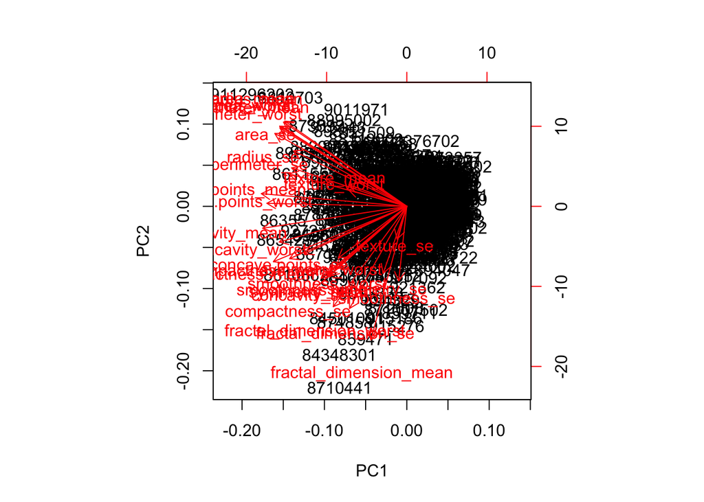

```r
biplot(wisc.pr)
```

Q7: This plot is pretty messy, and nearly impossible to interpret what is going on. A simpler plot of PC1 vs PC2 is much easier to make sense of.

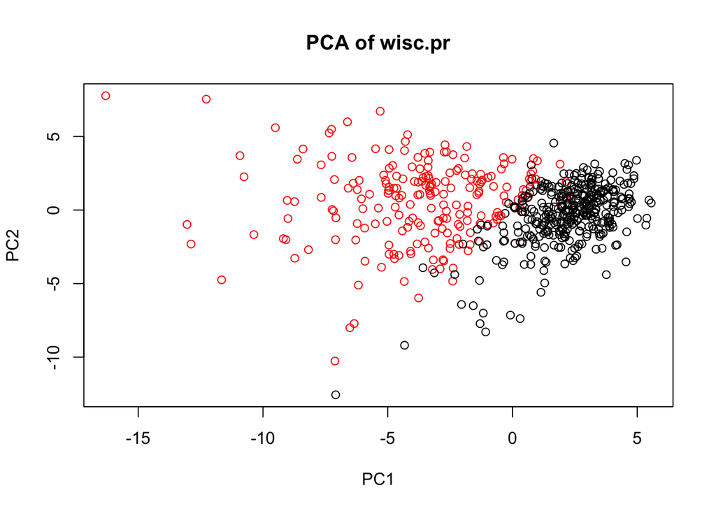

```r
plot(wisc.pr$x,  col = diagnosis + 1, main = "PCA of wisc.pr")
```

This plot shows that PC1 is capturing the variance between benign and malignant samples (since we colored based on our diagnostic data)

Here we calculate the variance captured by each principal component.

```r
pr.var <- (wisc.pr$sdev)^2
head(pr.var)
```

```
## [1] 13.281608  5.691355  2.817949  1.980640  1.648731  1.207357
```

Here is the proportion of variance captured by each;

```r
pve <- round(100*pr.var/(sum(pr.var)), digits = 2)
pve
```

```
##  [1] 44.27 18.97  9.39  6.60  5.50  4.02  2.25  1.59  1.39  1.17  0.98
## [12]  0.87  0.80  0.52  0.31  0.27  0.20  0.18  0.16  0.10  0.10  0.09
## [23]  0.08  0.06  0.05  0.03  0.02  0.01  0.00  0.00
```

Now we plot variance explained by each PC (Scree plots):

Here is with a line/dot plot:

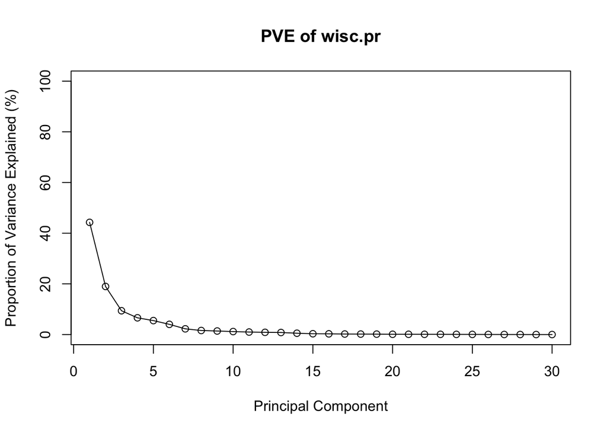

```r
plot(pve, xlab = "Principal Component", ylab = "Proportion of Variance Explained (%)", main = "PVE of wisc.pr",ylim = c(0,100), typ = "o")
```

And alternatively, with a barplot:

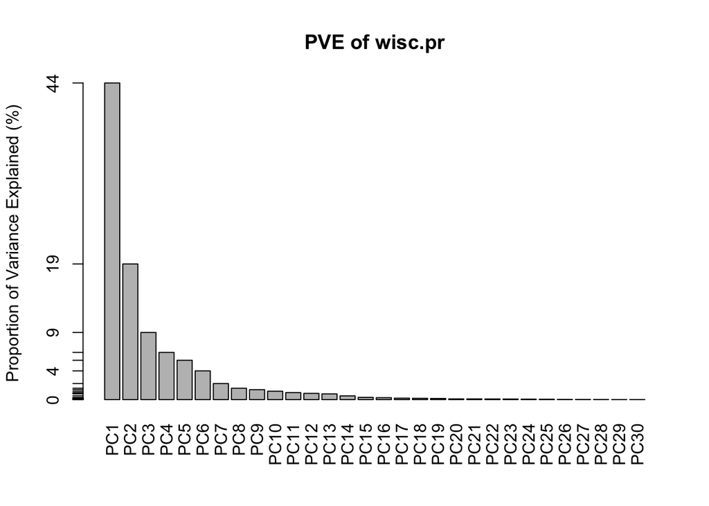

```r
barplot(pve, ylab = "Proportion of Variance Explained (%)",
        main = "PVE of wisc.pr",
        names.arg=paste0("PC",1:length(pve)), las = 2,
        axes = F)
axis(2, at = pve, labels = round(pve,0))
```

Now we plot cuulative proportion of variance explained:

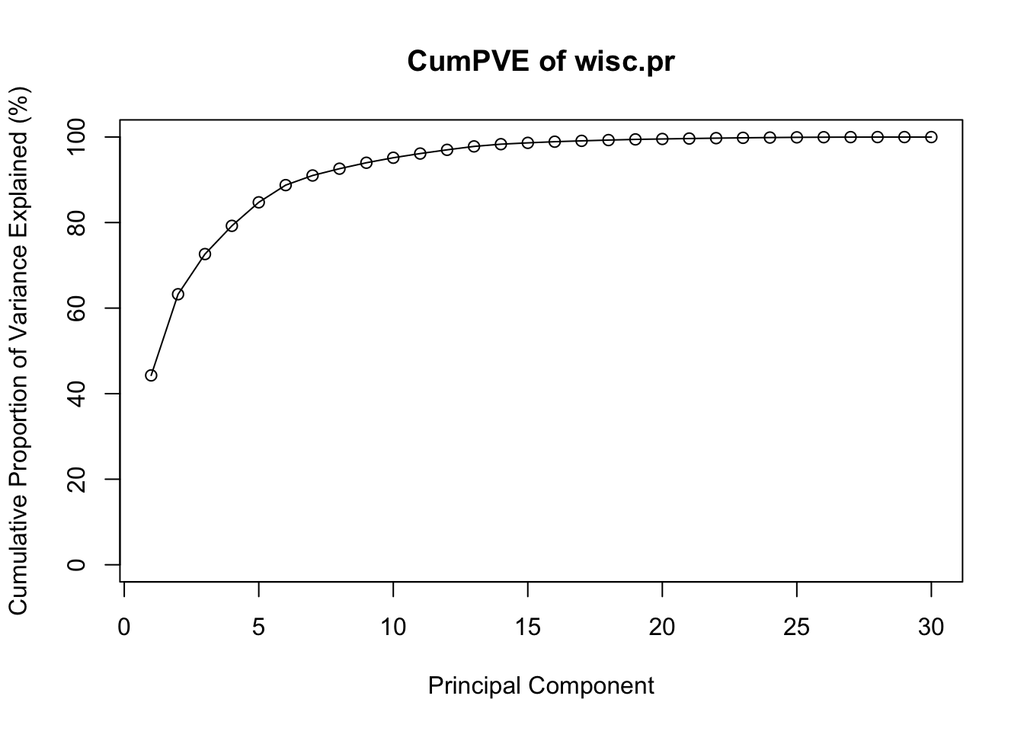

```r
plot(cumsum(pve), xlab = "Principal Component",
     ylab = "Cumulative Proportion of Variance Explained (%)",
     main = "CumPVE of wisc.pr",ylim = c(0,100), typ = "o")
```

Then we make a side-by-side joining of both the PVE and CumPVE plots.

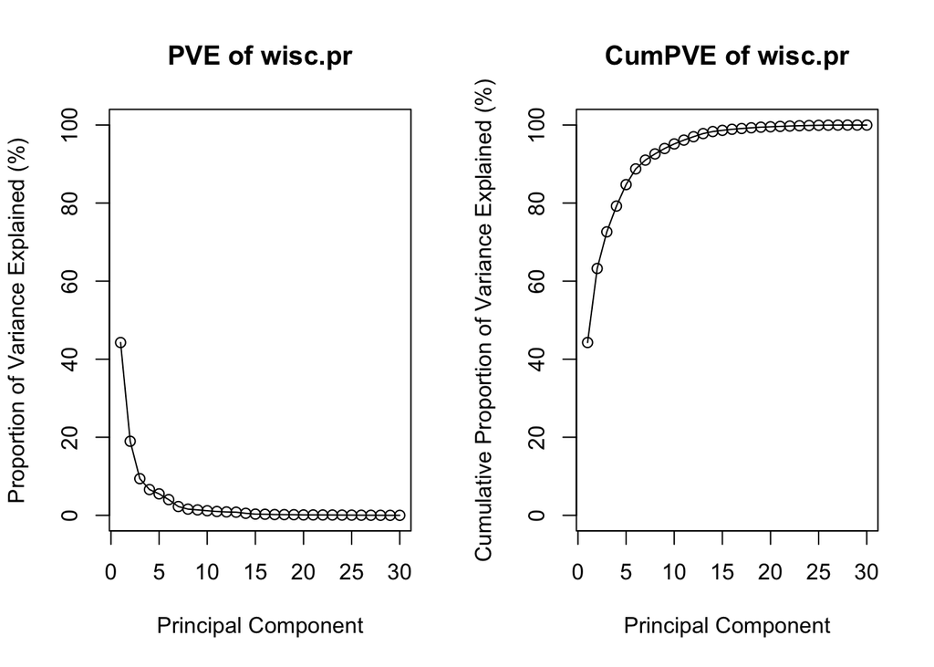

```r
par(mfrow=c(1,2))
plot(pve, xlab = "Principal Component",
     ylab = "Proportion of Variance Explained (%)",
     main = "PVE of wisc.pr",ylim = c(0,100), typ = "o")
plot(cumsum(pve), xlab = "Principal Component",
     ylab = "Cumulative Proportion of Variance Explained (%)",
     main = "CumPVE of wisc.pr",ylim = c(0,100), typ = "o")
```

Now let’s shift to using the glory of ggplot2

```r
# install.packages("factoextra")
# Remove the # before the above call to install factoextra
library(factoextra)
```

Now: a beautiful, one line scree plot.

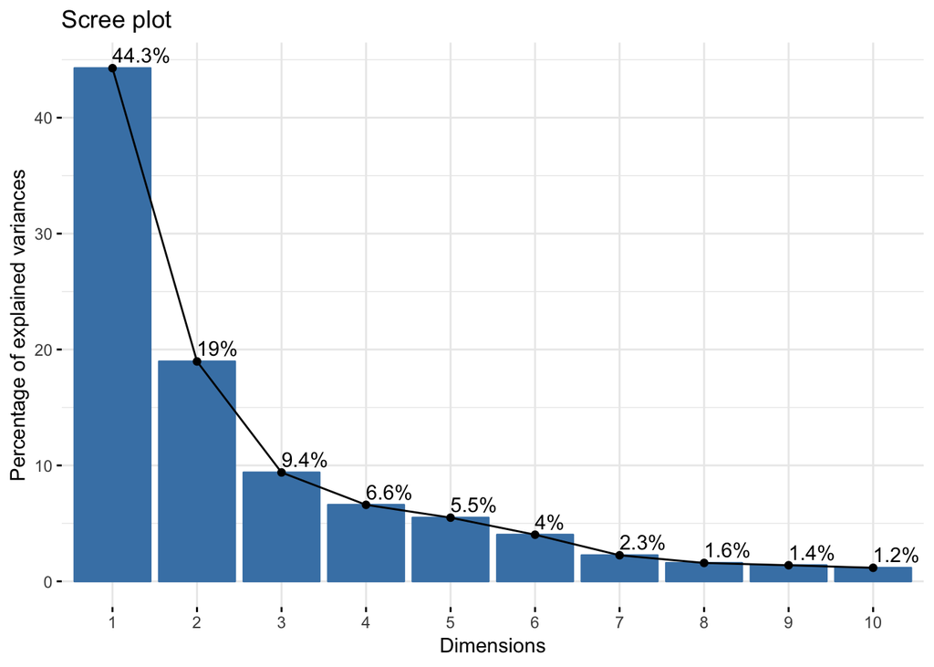

```r
fviz_eig(wisc.pr, addlabels = T)
```

### Communicating PCA Results

Q9: concave.points_mean is -0.26085376.

```r
load_wisc <- wisc.pr$rotation[,1]
```

Q10 The minimum number of principle components required for understanding 80% of the data: 5 PC’s, see below in the cumsum(pve) call.

```r
cumsum(pve)
```

```
##  [1] 44.27 63.24 72.63 79.23 84.73 88.75 91.00 92.59 93.98 95.15 96.13
## [12] 97.00 97.80 98.32 98.63 98.90 99.10 99.28 99.44 99.54 99.64 99.73
## [23] 99.81 99.87 99.92 99.95 99.97 99.98 99.98 99.98
```

```r
cumsum(pve) >= 80
```

```
##  [1] FALSE FALSE FALSE FALSE  TRUE  TRUE  TRUE  TRUE  TRUE  TRUE  TRUE
## [12]  TRUE  TRUE  TRUE  TRUE  TRUE  TRUE  TRUE  TRUE  TRUE  TRUE  TRUE
## [23]  TRUE  TRUE  TRUE  TRUE  TRUE  TRUE  TRUE  TRUE
```

## Part 3: Hierarchical clustering.

First we scale our data.

```r
data.scaled <- scale(wisc.data)
head(data.scaled)
```

```
##          radius_mean texture_mean perimeter_mean  area_mean
## 842302     1.0960995   -2.0715123      1.2688173  0.9835095
## 842517     1.8282120   -0.3533215      1.6844726  1.9070303
## 84300903   1.5784992    0.4557859      1.5651260  1.5575132
## 84348301  -0.7682333    0.2535091     -0.5921661 -0.7637917
## 84358402   1.7487579   -1.1508038      1.7750113  1.8246238
## 843786    -0.4759559   -0.8346009     -0.3868077 -0.5052059
##          smoothness_mean compactness_mean concavity_mean
## 842302         1.5670875        3.2806281     2.65054179
## 842517        -0.8262354       -0.4866435    -0.02382489
## 84300903       0.9413821        1.0519999     1.36227979
## 84348301       3.2806668        3.3999174     1.91421287
## 84358402       0.2801253        0.5388663     1.36980615
## 843786         2.2354545        1.2432416     0.86554001
##          concave.points_mean symmetry_mean fractal_dimension_mean
```

[output cut: 41 more lines]

First we calculate Euclidean distances between observations:

```r
data.dist = dist(data.scaled)
head(data.dist)
```

```
## [1] 10.309426  6.771675 10.463467  8.663413  8.402233  9.843286
```

Next, we cluster with hclust()

```r
wisc.hclust <- hclust(data.dist, "complete")
wisc.hclust
```

```
##
## Call:
## hclust(d = data.dist, method = "complete")
##
## Cluster method   : complete
## Distance         : euclidean
## Number of objects: 569
```

### Hierarchical Clustering: Results

Q11:

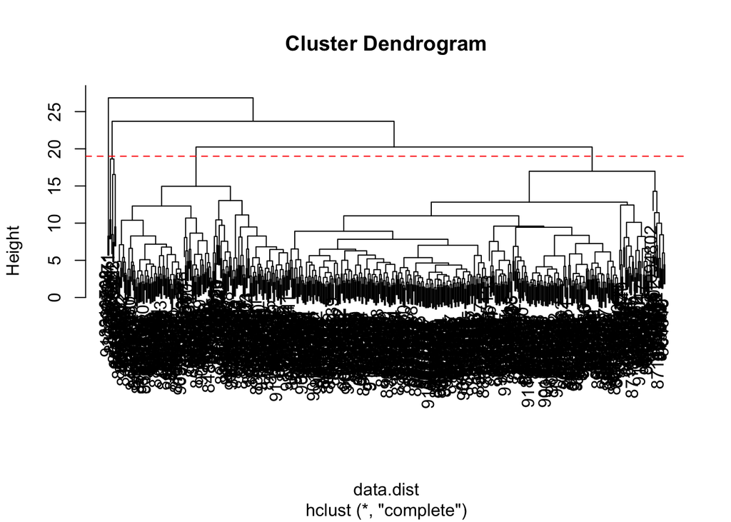

```r
plot(wisc.hclust)
abline(h = 19, col = "red", lty = 2)
```

```r
wisc.hclust.clusters <- cutree(wisc.hclust, k = 4)

table(wisc.hclust.clusters)
```

```
## wisc.hclust.clusters
##   1   2   3   4
## 177   7 383   2
```

Use the table() function to compare cluster emmbership to actual diagnosis:

```r
table(wisc.hclust.clusters, diagnosis)
```

```
##                     diagnosis
## wisc.hclust.clusters   0   1
##                    1  12 165
##                    2   2   5
##                    3 343  40
##                    4   0   2
```

## Part 5: Combination Methods

Combining our PCA with Hclust.

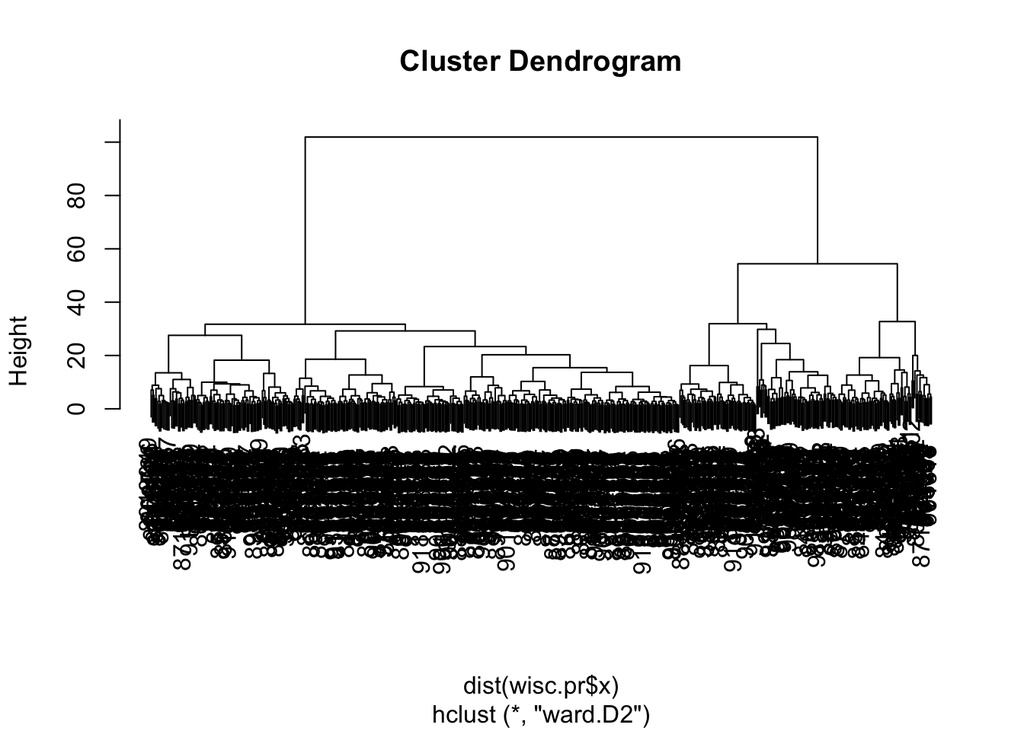

```r
# cumsum(pve) >= 90
wisc.pr_90 <- wisc.pr$x[1:7]
wisc.pca.hclust <-  hclust(dist(wisc.pr$x), method = "ward.D2")

plot(wisc.pca.hclust)
```

This gives us a much more legible dendogram which still represents the two major groups in the data seen in the original data.

Let’s see how many clusters exist in each:

```r
gprs <- cutree(wisc.pca.hclust,k = 2)

table(gprs)
```

```
## gprs
##   1   2
## 184 385
```

```r
table(gprs,diagnosis)
```

```
##     diagnosis
## gprs   0   1
##    1  20 164
##    2 337  48
```

Now we can do some PCA plotting using the data obtained from hclust.

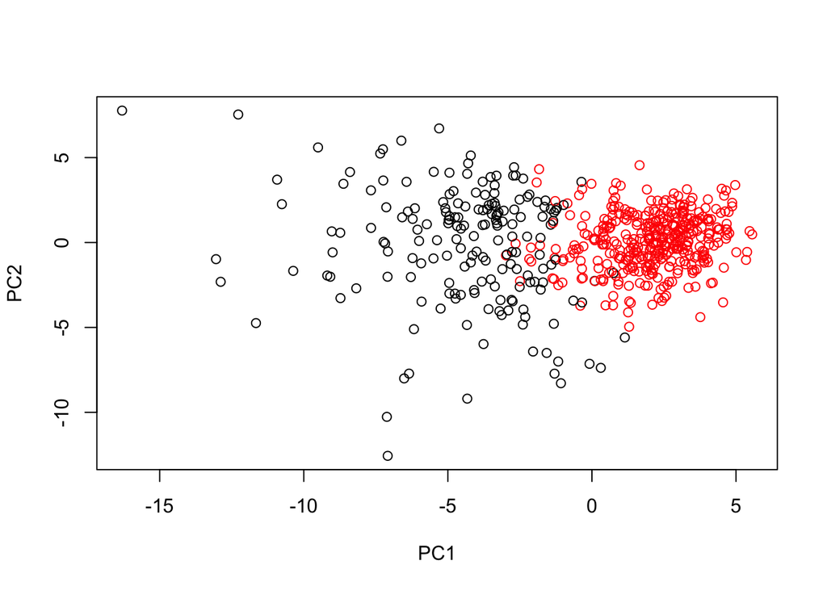

```r
plot(wisc.pr$x[,1:2], col = gprs)
```

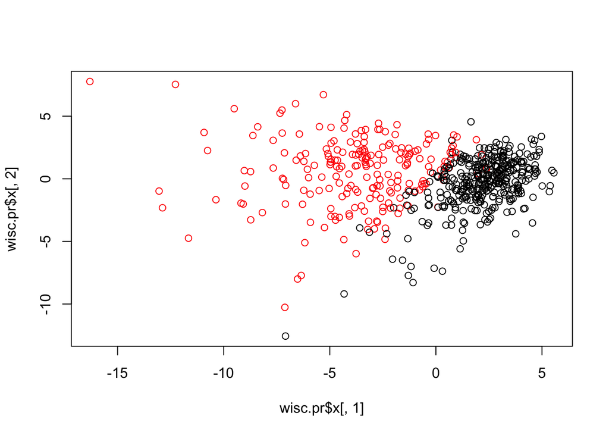

```r
plot(wisc.pr$x[,1], wisc.pr$x[,2], col = (diagnosis + 1))
```

#### Now to look at our data in 3D using the rgl package:

```r
#install.packages("rgl")
library(rgl)
```

```r
plot3d(wisc.pr$x[,1:3], xlab="PC 1", ylab="PC 2", zlab="PC 3", cex=1.5, size=1, type="s", col=diagnosis+1)

#plot3d(wisc.pr$x[,1:3],
#       xlab = "PC1", ylab = "PC2", zlab = "PC3",
 #      main = "PCA Plot of Wisconsin Cancer Data",
  #      cex = 1.5, typ = "s", size  = 1,
   #       col = (diagnosis + 1))
```